# Week 5: Data Manipulation - Class Exercises

We first load the packages necessary for this exercise.

```python
import pandas as pd
import matplotlib.pyplot as plt
from nycflights13 import flights
```

## Flights in New York City in 2013

In this question, we use the `flights` data set from the `nycflights13` package.

1. Remove cancelled flights (i.e., missing `dep_time`) and compute:

   (a) The number of flights that flew to Houston (with either `IAH` or `HOU` as the flight destination).

   (b) For each origin airport, compute the average departure delay. Which airport was the most punctual (with the lowest average departure delay)?

   **Hint**: For (a), check out the `subset` parameter in the `pandas` `dropna()` method.

```python
#   Your Code Here

df = flights.dropna(subset = ['dep_time'])

df1 = df[df['dest'].isin(['IAH', 'HOU'])]
print(df1.shape)

df2 = df.groupby('origin')[['dep_delay']].mean().reset_index()
df2.sort_values('dep_delay', ascending = True)
```

```
(9193, 19)
```

|  | origin | dep_delay |
| --- | --- | --- |
| 2 | LGA | 10.346876 |
| 1 | JFK | 12.112159 |
| 0 | EWR | 15.107954 |

*Your Answer*

(a) The number of flights that flew to Houston was **9193**.

(b) The most punctual airport was **LGA**.

2. For this part, we focus on flights that departed from the `JFK` airport and explore the average departure delay by scheduled departure hours:

   (a) Calculate the average departure delay for each scheduled departure hour of the day. Use the column `hour` as the hour of scheduled departure.

   (b) Re-create, as much as you can, the bar chart below to visualize the results.

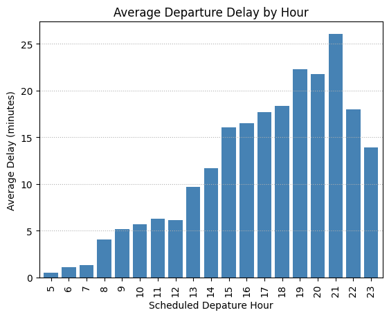

```
    hour  dep_delay
0      5   0.510724
1      6   1.113244
2      7   1.334720
3      8   4.090567
4      9   5.203929
5     10   5.683427
6     11   6.324407
7     12   6.159816
8     13   9.701588
9     14  11.673032
10    15  16.037580
11    16  16.507861
12    17  17.666394
13    18  18.392243
14    19  22.309884
15    20  21.747574
16    21  26.058599
17    22  17.997834
18    23  13.895610
```

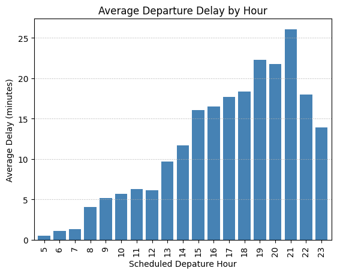

```python
#   Your Code Here

df3 = flights[flights['origin'] == 'JFK'].copy()
df4 = df3.groupby('hour')[['dep_delay']].mean().reset_index()
print(df4)

df4.plot(x = 'hour', y = 'dep_delay',
         kind = 'bar', width = 0.8,
         color = 'steelblue', legend = False,
         xlabel = 'Scheduled Depature Hour',
         ylabel = 'Average Delay (minutes)',
         title = 'Average Departure Delay by Hour')
plt.grid(axis = 'y', linestyle = ':')
plt.show()
```